# POLS 2072Q

Lecture 2 | Introduction to R and RStudio

## If You are Worried Because…

- You have never done any statistics or coding…
  - Don’t worry, I assume you haven’t
- Math is your “mortal enemy” or “you are not good at it”…
  - We will start from zero and progress slowly
  - There is plenty of help available
  - As long as you put in the time to do the work every week, you will do great!
- You don’t think you will be able to “memorize” all the equations …
  - You really shouldn’t have to memorize anything in this class

## Plan for Today

- Become familiar with R and RStudio
- Become familiar with R
  - Do calculations: +, -, \(*\), /
  - Create objects: \(<-\), “
  - Use functions: (), sqrt(), #

## R and RStudio

- Recall, before class today you should have installed two programs in your computer:
  - R () and RStudio ()
- R is the statistical program that will perform calculations and create graphics for us (it’s the engine)
- RStudio is the user-friendly interface that we will use to communicate with R
- We will never open R directly; we will always start by opening RStudio
  - RStudio will open R by itself

## RStudio

- Go ahead and open RStudio ()
- Then, open a new R script:
  - drop down menu: File > New File > R Script
- What is a R script?
  - type of file we use to store the code we write to analyze data

## RStudio Layout

[figure not shown]

## RStudio Layout

- R Script (upper left window):
  - Where we write and execute code
- R Console (lower left window):
  - where R provides the executed code and its outputs (including errors)
- Environment (upper right window):
  - Storage room of current R session
  - Lists objects that we have created
- Help and Plots tabs (lower right window)

## The R Programming Language

- To use R, we need to learn its language
  - the R programming language
  - R is both the name of the program and the name of the language
- Learning a programming language is like learning a foreign language
  - not easy
  - requires practice
  - requires patience

## We will use R to:

- Do calculations
- Create objects
- Use functions

## Calculations

- We can use R as a fancy calculator
  - R understands arithmetic operators such as +, -, \(*\), /
- Let’s ask R to calculate 20 plus 5
- First we type on the R script (upper left window): 20 + 5
- Then, to execute this code: we highlight it and either
  1. Manually hit the run icon ()
  2. Use the shortcut *command + enter* in **Mac** or *ctrl + enter* in **Windows**
- Go ahead and do it
- In the console, you should see the following:

```r
20 + 5
```

```
## [1] 25
```

- First, the executed code 20 + 5
  - Then, the output of the executed code ## [1] 25
- What does the [1] mean?
  - It indicates that the output immediately to its right is the first (and only, in this case) output
- The title of the R script is now highlighted in a different color to indicate that you have unsaved changes
  - To save the R script either use shortcuts (command + S or ctr + S) or click on File > Save (or Save As…)
  - Name it “lecture2” so that you know what it refers to
- In our textbooks, as well as in our lectures, you will probably see the output that you should see in the console right after the code that produces it, like so:
  - 20 + 5
  - ## [1] 25
- 20 + 5 is the code to be typed and executed on the R script (the code that R will execute)
- The symbol ## indicates the beginning of the output
- [1] 25 is the output (what you should see in the console after the executed code)

## Create Objects

- R Stores information in the form of objects
- In order to analyze data, we will need to create objects
- An object is like a box that can contain anything
  - To create an object, we need to:
    - Give it name
    - Specify its contents
    - Use the assignment operator \(<-\)

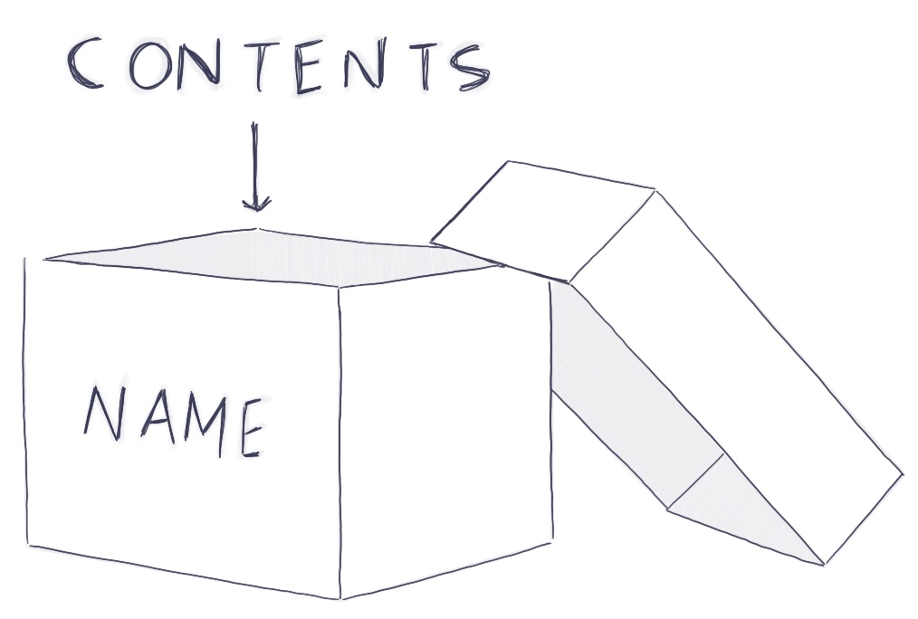

In R, we use the assignment operator \(<-\) to create an object:

- To its left, we specify the name of the object
  - A name cannot begin with a number, contain spaces, or special symbols (i.e., $ or %) that are reserved for other purposes
  - A name can contain _ underscores, which are good substitutes for spaces
- To its right, we specify the content of the object

object_name \(<-\) object_content

object_name \(<-\) object_content

- For example, type and run:

- After executing this code, the object *twentyfive* will show up in the Environment (the upper right window of RStudio)
- To find out the contents of an object, you can run the name of the object in R:

```r
twentyfive <- 25

twentyfive
```

```
## [1] 25
```

- Objects can contain text as well as numbers
- Execute: class \(<-\) “pols2072Q”
- Now in the environment there should be two objects
  - What are they?
- Note that in this last piece of code we used “ around the contents, but we did not use “ in the previous piece of code

twentyfive \(<-\) 25 vs class \(<-\) “pols2072Q”

- Why?

When do we need to use “ when writing code in R?

```r
class <- "pols2072Q"

class
```

```
## [1] "pols2072Q"
```

```r
##########

class <- "data analysis"

class
```

```
## [1] "data analysis"
```

- Notice that class now contains the text “data analysis” instead of “pols2072Q”
- R is case sensitive
  - *class* is different than *Class*
  - To avoid confusion, try to utilize lower-case letters when naming objects

## Use Functions

- Think of a function as an action that you request R to perform on a particular object or piece of data, such as calculating the square root of 25

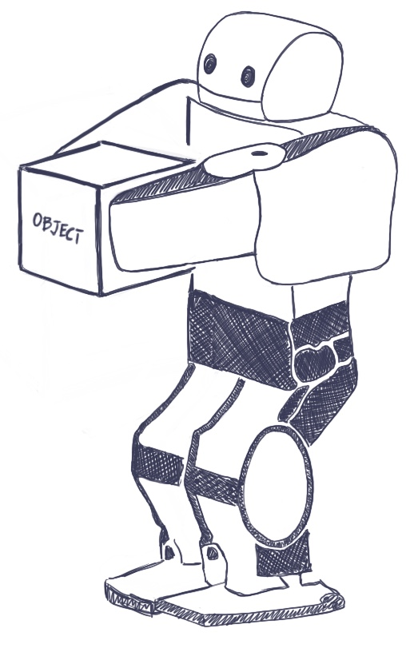

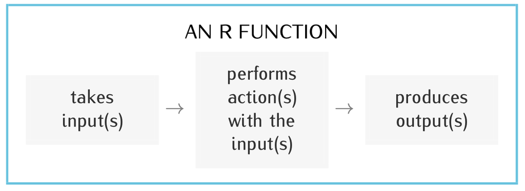

- A function:
  - takes input(s)
    - example: takes the number 25
  - Performs an action with the input(s)
    - computes \(\sqrt{25}\)
  - Produces an output
    - Produces the number 5
- We will learn how to use these functions and others throughout this semester:
  - sqrt(), setwd(), read.csv, View(), head(), dim(), mean(), ifelse(), table(), prop.table(), ggplot(), median(), lm(), print(), and summary()
- In time, we will learn:
  - Their names
  - The actions they perform
  - The inputs they require
  - The outputs they produce
- The name of a function (without quotes) is always followed by parentheses: function_name()
- Inside the parentheses, we specify the inputs, which we refer to as arguments: function_name(arguments)
- Most functions require that we specify at least one argument but can take many optional arguments
  - some arguments are required, others are optional
- When multiple arguments are specified inside the parentheses, they are separated by commas: function_name(argument1, argument2)
- To specify the arguments, we enter them in a particular order or include the name of the argument (without quotes) in our specification:
  - function_name(argument1, argument2)
  - function_name(argument1_name = argument1, argument2_name = argument2)
- We always specify required arguments first
- If there is more than one required argument, we enter them in the order expected by R
- We specify any optional arguments we want next and include their names:
  - function_name(required_arguments, optional_argument_name = optional_argument)

## Function Example

- Suppose R were capable of baking and that it had a function named bake() that, by default, bakes the specified ingredient for 60 minutes at 400F
- Required argument = the ingredient
  - Our ingredient is cake mix
- Optional arguments: named degrees and minutes to change the default temperature and duration of the bake, respectively
  - degrees = 350 which changes the temperature to 350F
  - minutes = 30 which changes the duration of bake to 30 minutes
- The following code would ask R to bake a cake mix for 30 minutes at 350F, so that we can have cake as the output:

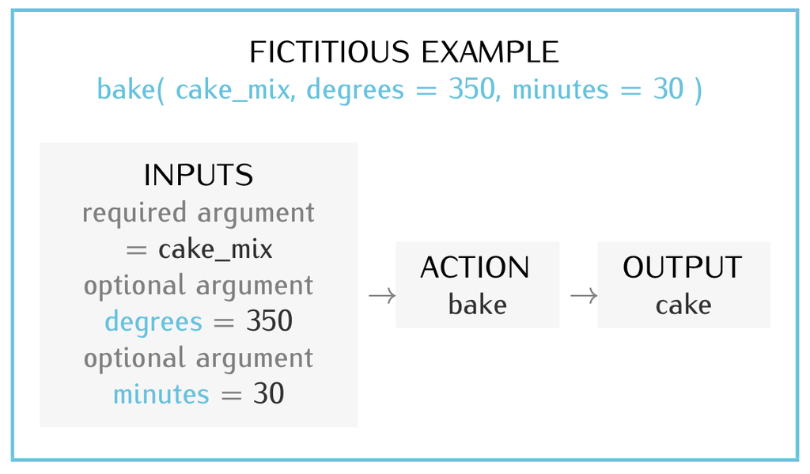

## Function Example Part Deux

- sqrt() computes the square root of the argument specified inside the parentheses. To compute \(\sqrt{25}\), run:

```r
sqrt(25)
```

```
## [1] 5
```

- sqrt is the name of the function, which, as all function names, is followed by parentheses ()
- 25 is the required argument
- 5 is the output
- Alternatively, since the object *twentyfive* contains the number 25, we can run:

```r
sqrt(twentyfive)
```

```
## [1] 5
```

- R will give you an error message if you run this line of code before creating the object *twentyfive*
- Code is sequential! One must run code in order
  - Whenever returning to work on an R script, run all the code from the beginning

## Good Coding Practices

- It is good practice to comment code
  - Include short notes to yourself or your collaborators explaining what the code does
- To comment code, we use #
  - R ignores everything that follows this character until the end of the line

```r
#calculate the square root
sqrt(25)
```

```
## [1] 5
```

```r
sqrt(25) #calculates square root of 25
```

```
## [1] 5
```

- Before closing your computer, remember to save the R script, otherwise you risk losing unsaved changes
  - Either use shortcuts (command + S or ctr + S)
  - Click on File > Save
- If you quit RStudio, R will ask whether you want to save the work space image, which contains all the objects you have created during the R session
  - I recommend that you do not save it
  - You can always re-create the objects by re-running the code in your R script

## For Next Class

- Review what you learned today
- Do new set of readings: DASS Chapter 1.7 - 1.10
  - Follow along the exercises with your own computer
- Bring your laptops to class